# Projekt zaliczeniowy

Jakub Zięba

2022-11-27

```r
nazwyPol <- c("panstwo","rok","smiertelnosc_dzieci","emisja_co2","smierci_w_katastrofach","hdi","gdpPerCap","procent_pracownikow_w_przemysle",
              "przewidywana_dlug_zycia","nowe_przyp_raka_pluc_M","nowe_przyp_raka_pluc_K",
              "sustainable_development_indeks")
colnames(dane) <- nazwyPol
```

# 1. Czy odsetek społeczeństwa zatrudnionego w przemyśle ma wpływ na poziom emisji CO2?

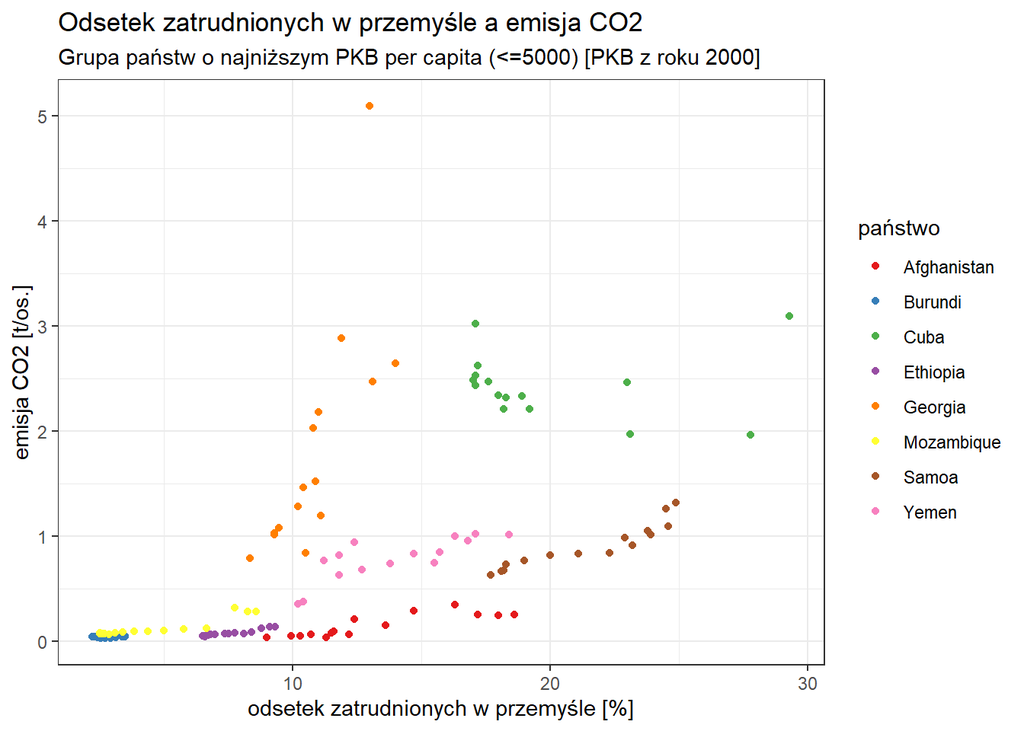

```r
PKB_grupa1_top <- dane %>%
  filter(gdpPerCap<=5000) %>%
  filter(rok==2000) %>%
  slice_max(gdpPerCap,n=4)
PKB_grupa1_bot <- dane %>%
  filter(gdpPerCap<=5000) %>%
  filter(rok==2000) %>%
  slice_min(gdpPerCap,n=4)

PKB_grupa1_W <- rbind(PKB_grupa1_bot,PKB_grupa1_top)

PKB_grupa1 <- dane %>%
  filter(panstwo %in% PKB_grupa1_W$panstwo)

PKB_grupa1 %>%
  ggplot() +
  geom_point(mapping = aes(x=procent_pracownikow_w_przemysle,
                           y=emisja_co2,
                           col=panstwo)) +
    theme_bw() +
      scale_color_brewer(palette = "Set1") +
        labs(title = "Odsetek zatrudnionych w przemyśle a emisja CO2",
             subtitle = "Grupa państw o najniższym PKB per capita (<=5000) [PKB z roku 2000]",
             x = "odsetek zatrudnionych w przemyśle [%]",
             y = "emisja CO2 [t/os.]",
             col = "państwo")
```

W grupie państw o PKB per capita mniejszym od 5000 widać że niski odsetek społeczeństwa zatrudnionego w sektorze przemysłowym generalnie wiąże się z niską emisją CO2, podobnie jak wysoki odsetek wiąże się ze sporą emisją dwutlenku węgla. Sytuacja jest zróżnicowana dla państw, w których ten odsetek zawiera się w przedziale pomiędzy 10% a 20%. Tutaj na przestrzeni lat sytuacja zmienia się i nie ma reguły. Dla niektórych państw emisja CO2 utrzymuje się na poziomie 1 tony/osobę, w innych przypadkach przekracza trzykrotność tej wartości. Można jednak zauważyć pewien trend wzrostowy.

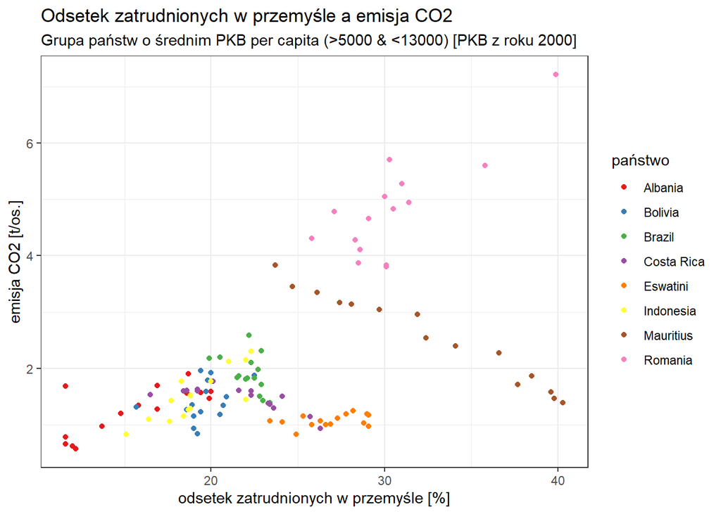

W drugiej grupie widać podobne zachowanie jak w grupie poprzedniej. W środkowej części osi OX wartości na osi OY są mocno rozrzucone.

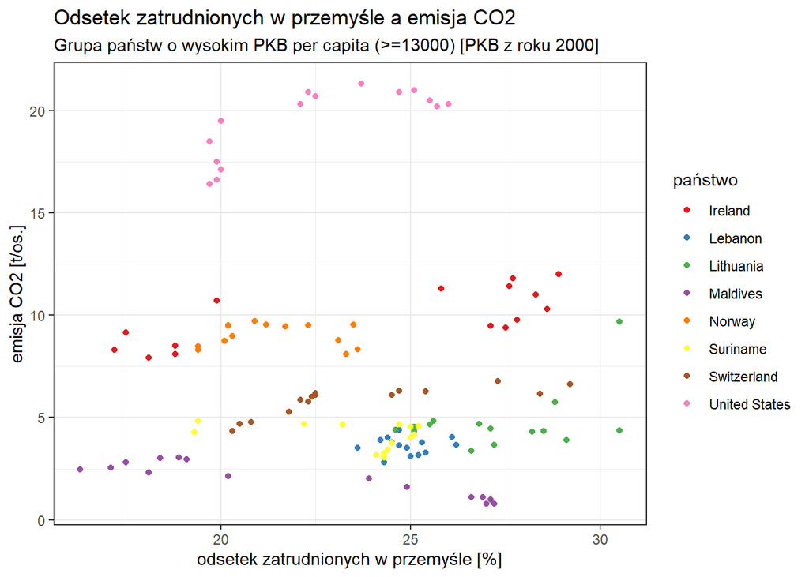

W grupie najbogatszej, w której państwa mogą pochwalić się wynikiem PKB per capita >= 13000 ciężko dopatrzeć się jakiegoś trendu. Zależnie od państwa, odsetek zatrudnionych w przemyśle wiąże się z niską lub wyższą emisją dwutlenku węgla.

```
## [1] "Statystyki opisowe dla grupy 1 (procent pracowników, emisja CO2):"
```

```
##    Min. 1st Qu.  Median    Mean 3rd Qu.    Max.
##    2.22    6.68   10.95   11.79   17.12   29.30
```

```
##    Min. 1st Qu.  Median    Mean 3rd Qu.    Max.
## 0.02350 0.06825 0.35050 0.79178 1.03500 5.09000
```

```
## [1] "Korelacja Spearmana pomiędzy zmiennymi w grupie 1 jest równa:"
```

```
## [1] 0.7628092
```

```
## [1] "Statystyki opisowe dla grupy 2 (procent pracowników, emisja CO2):"
```

```
##    Min. 1st Qu.  Median    Mean 3rd Qu.    Max.
##   11.60   19.15   22.30   23.50   27.50   40.30
```

```
##    Min. 1st Qu.  Median    Mean 3rd Qu.    Max.
##   0.563   1.215   1.585   1.998   2.158   7.220
```

```
## [1] "Korelacja Spearmana pomiędzy zmiennymi w grupie 2 jest równa:"
```

```
## [1] 0.4216155
```

```
## [1] "Statystyki opisowe dla grupy 3 (procent pracowników, emisja CO2):"
```

```
##    Min. 1st Qu.  Median    Mean 3rd Qu.    Max.
##   16.30   20.73   24.35   23.67   25.85   30.50
```

```
##    Min. 1st Qu.  Median    Mean 3rd Qu.    Max.
##   0.772   3.728   4.835   7.332   9.473  21.300
```

```
## [1] "Korelacja Spearmana pomiędzy zmiennymi w grupie 3 jest równa:"
```

```
## [1] -0.07463646
```

Powyższe statystki dobrze oddają nasze obserwacje. Dobrze sprawdza się przede wszystkim wskaźnik korelacji Spearmana. Dla grupy 1 jest on dość wysoki, a dla pozostałych dWóch grup niski lub bardzo niski, co dobrze oddaje zauważalne na wykresach zależności (lub ich brak).

Generalnie rzecz biorąc odsetek zatrudnionych w przemyśle ma wpływ na wysokość emisji dwutlenku węgla, ale nie jest to główny czynnik.

# 2. Czy zmieniająca się wysokość emisji dwutlenku węgla wpływa na wzmożenie skutków katastrof ekologicznych?

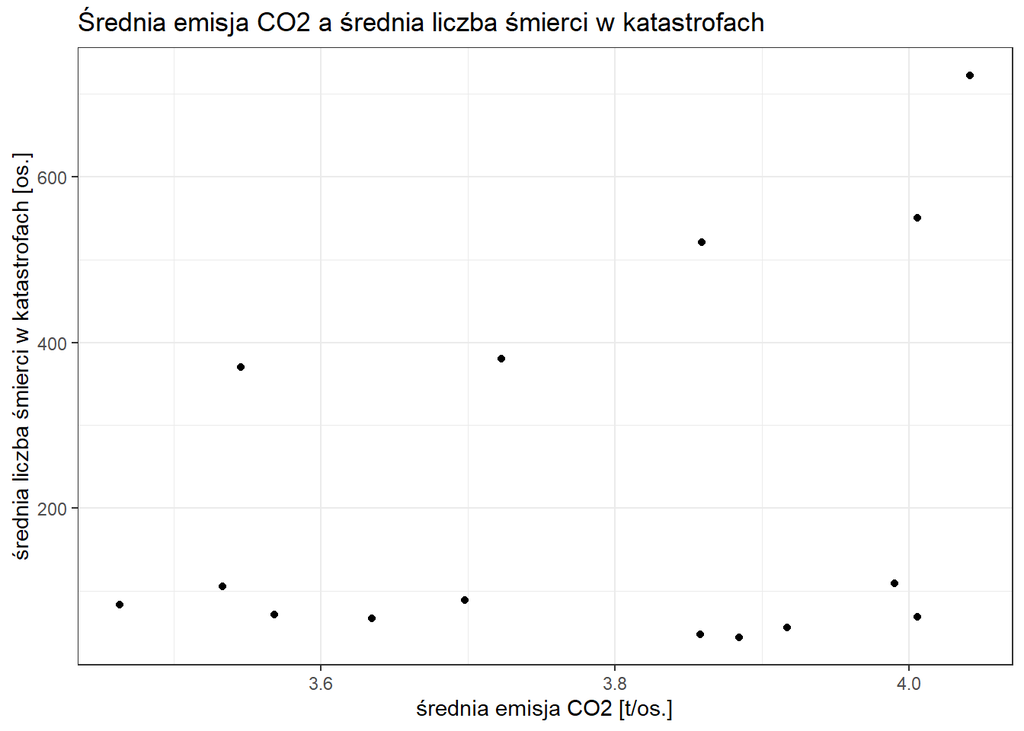

```r
katastrofy_bez_outl <- dane %>%
  filter(smierci_w_katastrofach>100000)

katastrofy_W <- dane %>%
  filter(!panstwo %in% katastrofy_bez_outl$panstwo)

srednia_smierci <- dane %>%
  group_by(rok) %>%
  summarise_at(vars(smierci_w_katastrofach),list(name=mean))

srednia_smierci_bez_outl <- katastrofy_W %>%
  group_by(rok) %>%
  summarise_at(vars(smierci_w_katastrofach),list(name=mean))

dwutlenek_wegla <- dane %>%
  filter(!panstwo %in% katastrofy_bez_outl$panstwo) %>%
  group_by(rok) %>%
  summarise_at(vars(emisja_co2),list(name=mean))

pyt2 <- data.frame(srednia_smierci_bez_outl,dwutlenek_wegla$name)
colnames(pyt2) <- c("rok","srednie_smierci","srednia_emisja_CO2")

pyt2 %>%
  ggplot(aes(x = srednia_emisja_CO2,
           y = srednie_smierci)) +
    geom_point() +
      #geom_smooth(method = "lm", formula = y ~ x, se=F, col="red") +
        theme_bw() +
          labs(title="Średnia emisja CO2 a średnia liczba śmierci w katastrofach ",
               x = "średnia emisja CO2 [t/os.]",
               y = "średnia liczba śmierci w katastrofach [os.]")
```

Patrząc na wykres można pomyśleć, że poziom emisji CO2 nie ma wielkiego wpływu na wielkość strat powodowanych przez katastrofy. Jednak należy tutaj zwrócić uwagę na fakt, że nie są to zjawiska powszechne, dlatego liczba śmierci nimi spowodowana nie jest wysoka co roku. Widać natomiast wzrost liczby śmierci względem emisji dwutlenku węgla wtedy, kiedy w.w. katastrofy już się wydarzą. W związku z tym myślę, że wpływu emisji dwutlenku węgla nie można zignorować jako jednego z czynników rosnącej skali katastrof.

# 3. Czy emisja CO2 ma wpływ na przewidywaną długość życia?

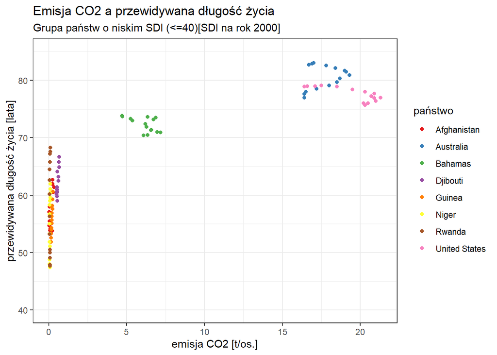

```r
sdi_grupa1_top <- dane %>%
  filter(sustainable_development_indeks <= 40) %>%
  filter(rok==2000) %>%
  slice_max(sustainable_development_indeks,n=4)
sdi_grupa1_bot <- dane %>%
  filter(sustainable_development_indeks <= 40) %>%
  filter(rok==2000) %>%
  slice_min(sustainable_development_indeks,n=4)

sdi_grupa1_W <- rbind(sdi_grupa1_bot, sdi_grupa1_top)
sdi_grupa1 <- dane %>%
  filter(panstwo %in% sdi_grupa1_W$panstwo)

sdi_grupa1 %>%
  ggplot() +
    geom_point(mapping = aes(x=emisja_co2,
                           y=przewidywana_dlug_zycia,
                           col=panstwo)) +
      ylim(40,85) +
        theme_bw() +
          scale_color_brewer(palette = "Set1") +
           labs(title = "Emisja CO2 a przewidywana długość życia",
              subtitle = "Grupa państw o niskim SDI (<=40)[SDI na rok 2000]",
              x = "emisja CO2 [t/os.]",
              y = "przewidywana długość życia [lata]",
              col = "państwo")
```

W pierwszej grupie, wyróżnionej na podstawie niskiego wskaźnika SDI można zobaczyć, że dla takich państw emisja dwutlenku węgla nie jest mocno związana z przewidywaną długością życia. Co ciekawe, część bogatych państw też zawiera się w tej grupie, zawyżając obie zmienne (np. Stany Zjednoczone).

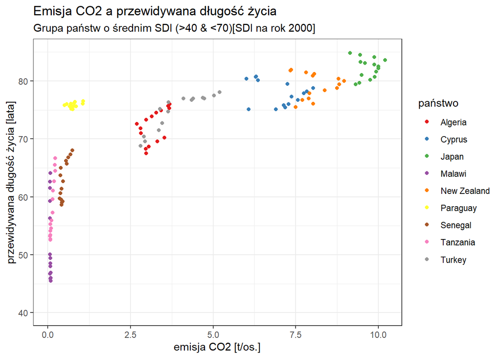

W grupie drugiej widać już pewną zależność, jednak nie taką jakiej można by się na pierwszy rzut oka spodziewać. Wzrost emisji CO2 nie wiąże się z obniżeniem przewidywanej długości życia, a w wielu przypadkach wręcz przeciwnie.

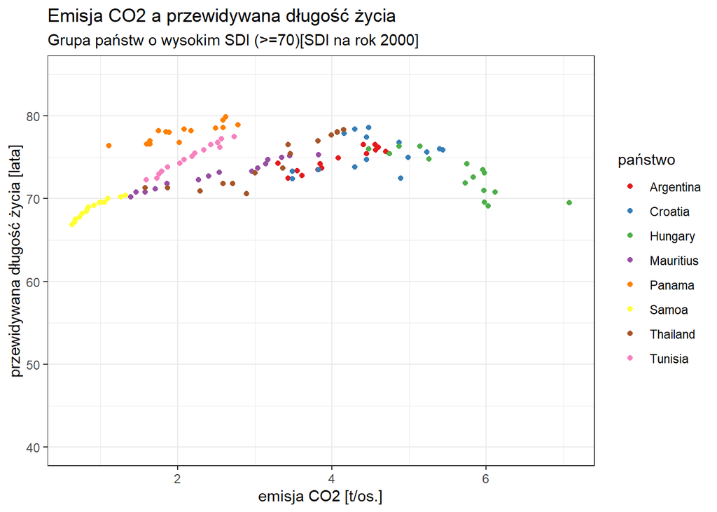

W grupie trzeciej sytuacja wygląda podobnie jak w grupie drugiej. Mimo zróżnicowanej emisji dwutlenku węgla, państwa w tej grupie posiadają wysoką przewidywaną długość życia.

Wszystkie trzy grupy pokazują, że emisja CO2 nie ma bezpośredniego wpływu na przewidywaną długość życia mieszkańca danego kraju. W zależności od pochodzenia tej emisji może być ona nawet czynnikiem wskazującym na dobre standardy jeśli chodzi o przewidywaną długość życia,

# 4. Jak wygląda poziom emisji CO2 dla państw, których HDI i SDI skrajnie się różnią?

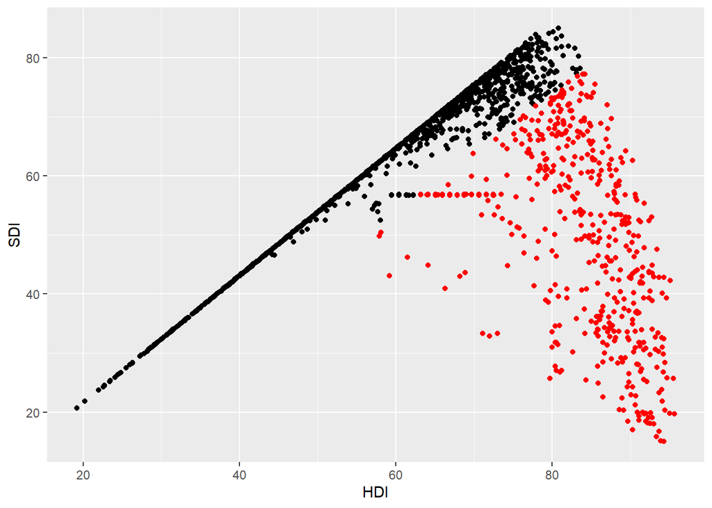

```r
dane2 <- dane %>%
  filter(rok==2000)

rozbiezne_hdi_sdi <- dane %>%
  filter(rok==2000) %>%
  filter(abs(sustainable_development_indeks-hdi*100)>6)

dane %>%
  ggplot() +
    geom_point(mapping = aes(x = hdi*100,
                             y = sustainable_development_indeks)) +
  filter(dane, abs(sustainable_development_indeks-hdi*100)>6) %>%
    geom_point(mapping = aes(x = hdi*100,
                             y = sustainable_development_indeks),
                             col = "red") +
    labs(title=,
         x="HDI",
         y="SDI")
```

Na wykresie widać, że dla większości państw HDI jest bardzo podobne do SDI. Istnieje jednak wiele przypadków w których ta różnica jest duża lub bardzo duża. Postanowiłem wyodrębnić właśnie te kraje.

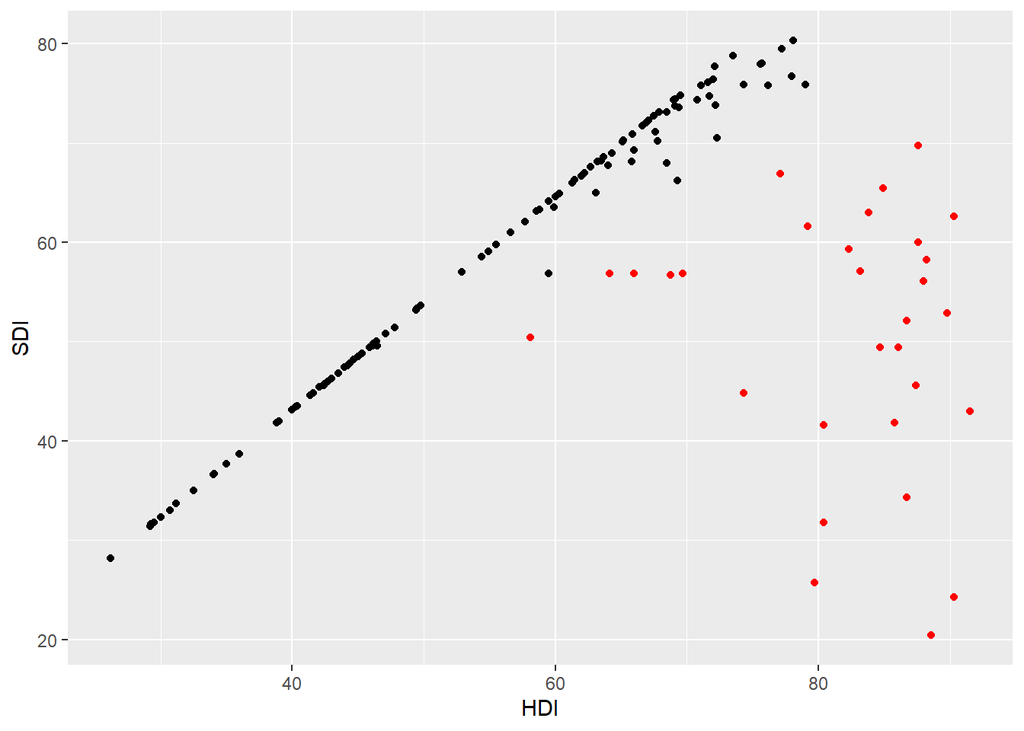

```r
dane2 %>%
  ggplot() +
  geom_point(mapping = aes(x = hdi*100,
                           y = sustainable_development_indeks)) +
  filter(dane2, abs(sustainable_development_indeks-hdi*100)>6) %>%
  geom_point(mapping = aes(x = hdi*100,
                           y = sustainable_development_indeks),
             col = "red") +
  labs(title=,
       x="HDI",
       y="SDI")
```

Po zawężeniu danych do roku 2000 obserwacja ta się nie zmienia.

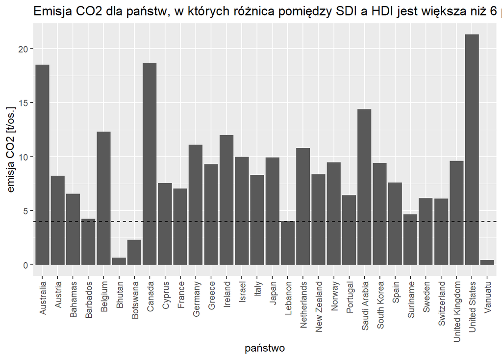

```r
rozbiezne_hdi_sdi %>%
  ggplot() +
    geom_col(mapping = aes(x=panstwo,
                           y=emisja_co2)) +
      scale_x_discrete(guide = guide_axis(angle = 90)) +
        labs(title="Emisja CO2 dla państw, w których różnica pomiędzy SDI a HDI jest większa niż 6 pp.",
             x="państwo",
             y="emisja CO2 [t/os.]") +
      geom_hline(yintercept=4, linetype="dashed")
```

W przypadku państw, w których różnica pomiędzy HDI a SDI jest większa niż 6 pp. widać, że niemal każde z nich cechuje się wysokim poziomem emisji dwutlenku węgla, powyżej wartości 4 ton/osobę. Tylko 3 państwa ze zbioru wyłamują się, i w ich przypadku emisja ta jest dużo mniejsza.

# 5. Czy liczba nowych zachorowań na raka płuc ma wpływ na wysokość indeksu HDI?

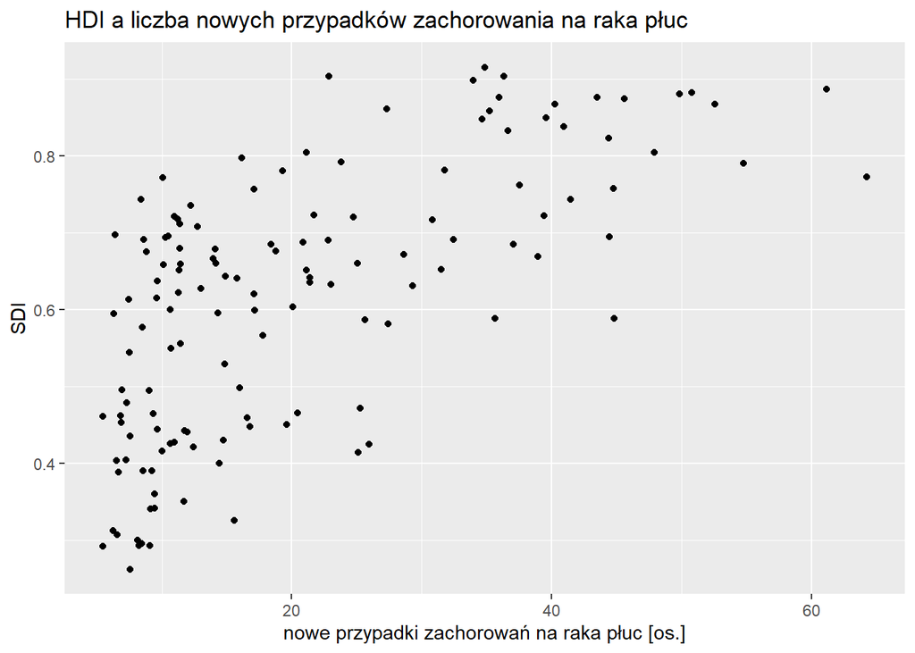

```r
nowe_przypadki_raka <- dane %>%
  mutate(nowe_przypadki_raka = (nowe_przyp_raka_pluc_M+nowe_przyp_raka_pluc_K)/2) %>%
  select(-nowe_przyp_raka_pluc_M,-nowe_przyp_raka_pluc_K)

nowe_przypadki_raka %>%
  filter(rok==2000) %>%
  ggplot(aes(x=nowe_przypadki_raka,
             y=hdi)) +
    geom_point() +
      #geom_smooth(method = "lm",formula = y ~ x, se=T) +
        labs(title="HDI a liczba nowych przypadków zachorowania na raka płuc",
             x="nowe przypadki zachorowań na raka płuc [os.]",
             y="SDI")
```

Wykres dla wszystkich państw nie byłby zbyt czytelny, dlatego tutaj państwa podzieliłem na grupy względem SDI z 2000 roku.

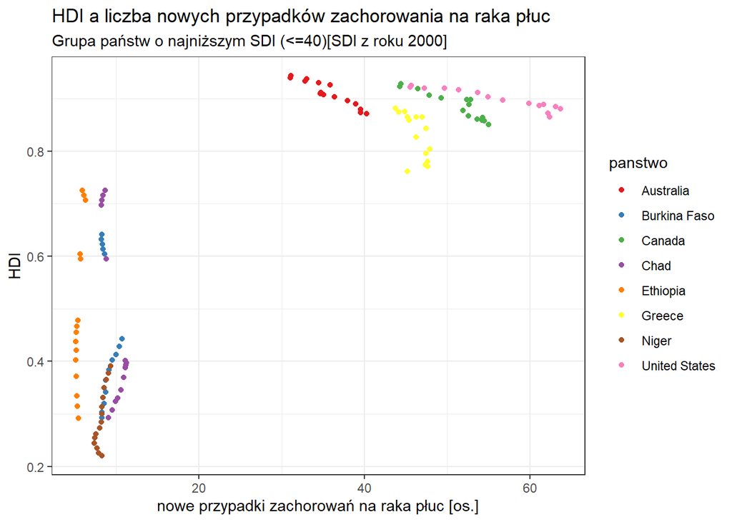

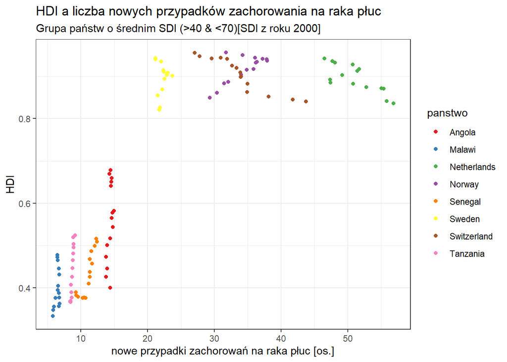

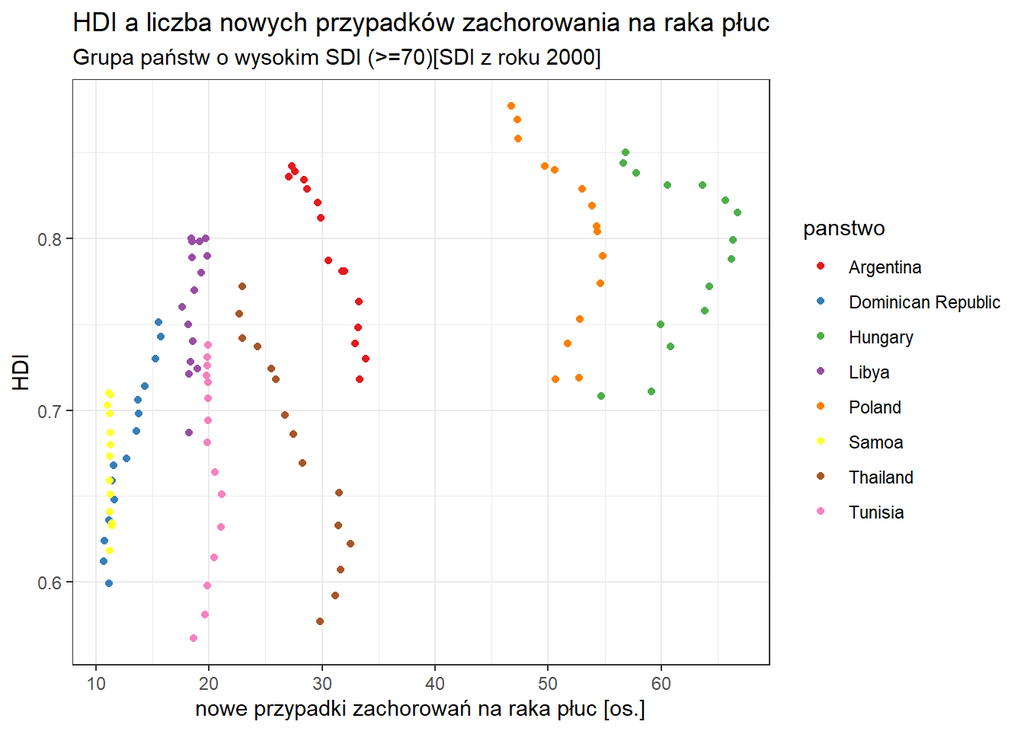

```r
sdi_grupa1_top <- dane %>%
  filter(sustainable_development_indeks <= 40) %>%
  filter(rok==2000) %>%
  slice_max(hdi,n=4)
sdi_grupa1_bot <- dane %>%
  filter(sustainable_development_indeks <= 40) %>%
  filter(rok==2000) %>%
  slice_min(hdi,n=4)

sdi_grupa1_W <- rbind(sdi_grupa1_bot, sdi_grupa1_top)
rak_grupa1 <- nowe_przypadki_raka %>%
  filter(panstwo %in% sdi_grupa1_W$panstwo)


rak_grupa1 %>%
  ggplot() +
  geom_point(mapping = aes(x=nowe_przypadki_raka,
                           y=hdi,
                           col=panstwo)) +
  theme_bw() +
  scale_color_brewer(palette = "Set1") +
  labs(title="HDI a liczba nowych przypadków zachorowania na raka płuc",
       subtitle = "Grupa państw o najniższym SDI (<=40)[SDI z roku 2000]",
       x="nowe przypadki zachorowań na raka płuc [os.]",
       y="HDI")
```

W przypadku tych dwóch zmiennych w zasadzie rozbicie na grupy nie prowadzi do żadnych nowych wniosków. Ciężko dopatrzeć się tutaj jakiejkolwiek zależności między zmiennymi. Na przestrzeni lat HDI zmieniało się, jednak dla większości państw liczba nowych przypadków zachorowań na raka pozostawała na podobnym poziomie i nie mogła mieć wpływu na w.w. indeks. Myślę na tej podstawie, że liczba nowych przypadków zachorowań na raka płuc nie ma bezpośredniego wpływu na wysokość wskaźnika HDI.

# 6. Czy emisja CO2 ma wpływ na ilość nowych przypadków zachorowań na raka płuc?

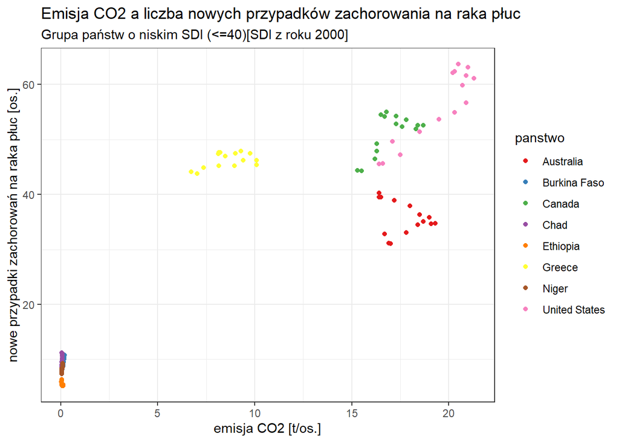

```r
sdi_grupa1_top <- dane %>%
  filter(sustainable_development_indeks <= 40) %>%
  filter(rok==2000) %>%
  slice_max(sustainable_development_indeks,n=4)
sdi_grupa1_bot <- dane %>%
  filter(sustainable_development_indeks <= 40) %>%
  filter(rok==2000) %>%
  slice_min(sustainable_development_indeks,n=4)

sdi_grupa1_W <- rbind(sdi_grupa1_bot, sdi_grupa1_top)
sdi_grupa1 <- dane %>%
  filter(panstwo %in% sdi_grupa1_W$panstwo)

rak_grupa1 %>%
  ggplot() +
  geom_point(mapping = aes(x=emisja_co2,
                           y=nowe_przypadki_raka,
                           col=panstwo)) +
  theme_bw() +
  scale_color_brewer(palette = "Set1") +
  labs(title="Emisja CO2 a liczba nowych przypadków zachorowania na raka płuc",
       subtitle = "Grupa państw o niskim SDI (<=40)[SDI z roku 2000]",
       x="emisja CO2 [t/os.]",
       y="nowe przypadki zachorowań na raka płuc [os.]")
```

W pierwszej grupie państw widać, że niskiej emisji CO2 towarzyszy mała liczba nowych przypadków zachorowania na raka płuc. Podobnie sytuacja ma się z wyższą emisją.

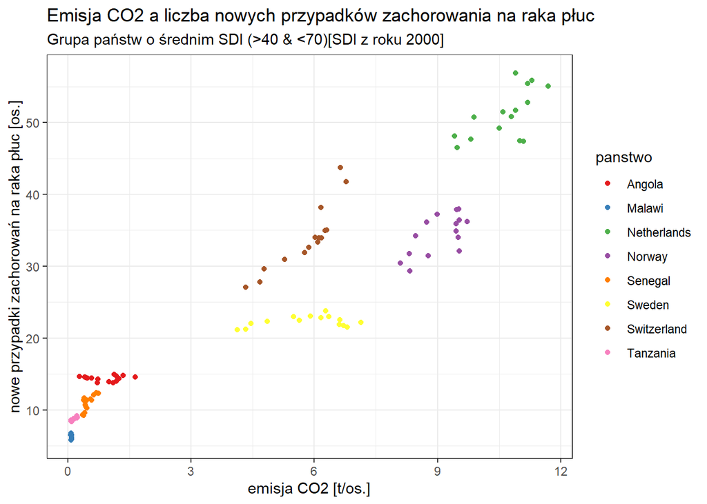

W grupie drugiej analogicznie jak poprzednio, wyższej emisji dwutlenku węgla towarzyszy wyższa liczba nowych zachorowań.

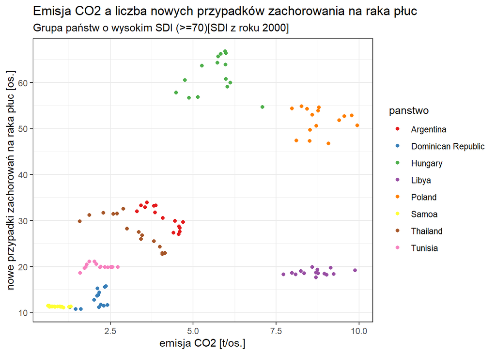

Dla państw w grupie trzeciej, posiadających najwyższe SDI sytuacja również wygląda podobnie, poza wyjątkiem jakim w tej grupie jest Libia, mająca bardzo wysoki poziom emisji CO2, a mimo tego utrzymująca niską liczbę nowych zachorowań na raka płuc.

```
## [1] "Statystyki opisowe dla grupy 1 (emisja CO2, nowe przypadki zachorowań na raka):"
```

```
##     Min.  1st Qu.   Median     Mean  3rd Qu.     Max.
##  0.03980  0.06918  3.46400  7.88657 16.92500 21.30000
```

```
##    Min. 1st Qu.  Median    Mean 3rd Qu.    Max.
##    5.12    8.30   21.13   27.66   47.27   63.70
```

```
## [1] "Korelacja Spearmana pomiędzy zmiennymi w grupie 1 jest równa:"
```

```
## [1] 0.8307245
```

```
## [1] "Statystyki opisowe dla grupy 2 (emisja CO2, nowe przypadki zachorowań na raka):"
```

```
##    Min. 1st Qu.  Median    Mean 3rd Qu.    Max.
##  0.0628  0.2707  2.8800  4.1191  7.3725 11.7000
```

```
##    Min. 1st Qu.  Median    Mean 3rd Qu.    Max.
##   5.775   9.225  18.040  22.777  34.000  56.850
```

```
## [1] "Korelacja Spearmana pomiędzy zmiennymi w grupie 2 jest równa:"
```

```
## [1] 0.9599479
```

```
## [1] "Statystyki opisowe dla grupy 3 (emisja CO2, nowe przypadki zachorowań na raka):"
```

```
##    Min. 1st Qu.  Median    Mean 3rd Qu.    Max.
##   0.631   2.120   3.820   4.441   7.240   9.940
```

```
##    Min. 1st Qu.  Median    Mean 3rd Qu.    Max.
##   10.71   17.17   21.91   29.29   37.11   66.75
```

```
## [1] "Korelacja Spearmana pomiędzy zmiennymi w grupie 3 jest równa:"
```

```
## [1] 0.6083685
```

Sytuację dobrze oddają też powyższe statystyki. Korelacja Spearmana jest bardzo wysoka dla pierwszych dwóch grup, natomiast ulega dość znacznemu zmniejszeniu dla grupy trzeciej.

Podsumowując, emisja dwutlenku węgla ma duży wpływ na liczbę nowych zachorowań na raka płuc. Prawdopodobnie nie jets to bezpośredni wpływ dwutlenku węgla, a procesów przez które powstaje, jednak nie można wywnioskować tego bezpośrednio z dostępnych danych.

#7. Czy wysoki odsetek zatrudnienia w przemyśle ma związek z wysokością SDI?

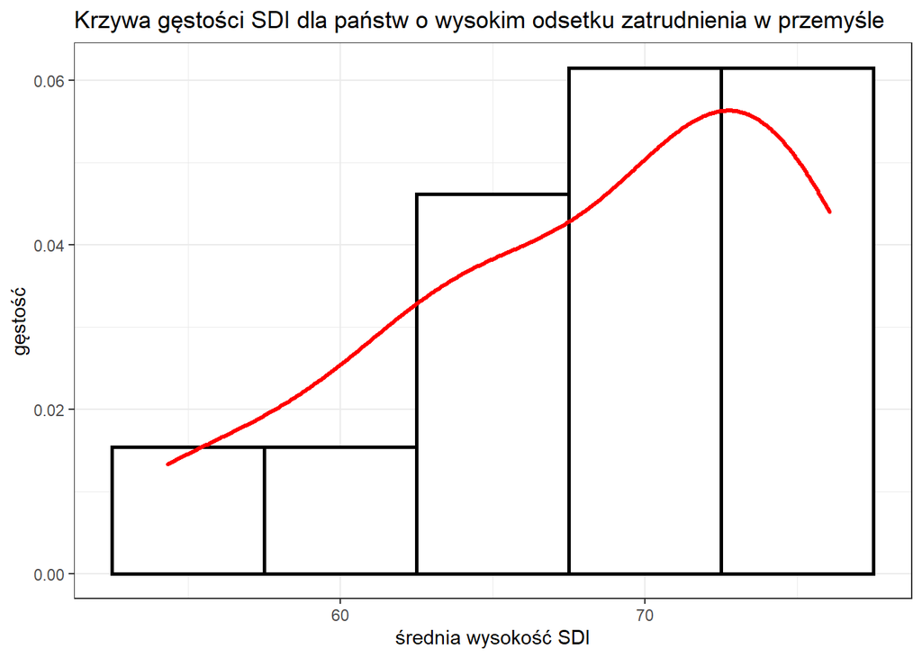

```r
zatrudnienie_w_przemysle_niskie <- dane %>%
  filter(procent_pracownikow_w_przemysle<25)
panstwa_niskie_zatrudnienie <- unique(zatrudnienie_w_przemysle_niskie$panstwo)
zatrudnienie_w_przemysle_wysokie <- dane %>%
  filter(!panstwo %in% panstwa_niskie_zatrudnienie)

zatrudnienie_w_przemysle_wysokie %>%
  group_by(panstwo) %>%
  summarise_at(vars(sustainable_development_indeks),list(name=mean)) %>%
  ggplot() +
    geom_histogram(mapping = aes(x=name,
                       y=..density..),
                   fill="white",
                   binwidth = 5,
                   color="black",
                   size=1) +
    geom_density(mapping = aes(x=name),
                 size=1.2,
                 color="red") +
        labs(title="Krzywa gęstości SDI dla państw o wysokim odsetku zatrudnienia w przemyśle",
             x="średnia wysokość SDI",
             y="gęstość") +
          theme_bw()
```

Jako wysoki odsetek społeczeństwa zatrudnionego w przemyśle uznałem państwa, które na przestrzeni lat nie schodziły w tej statystyce poniżej poziomu 25%. Wbrew moim oczekiwaniom, większość państw w tej grupie cechuje się również wysokim wskaźnikiem SDI, co pokazuje histogram oraz nałożona na niego krzywa gęstości.

# 8. Czy śmiertelność dzieci ma wpływ na wskaźnik SDI?

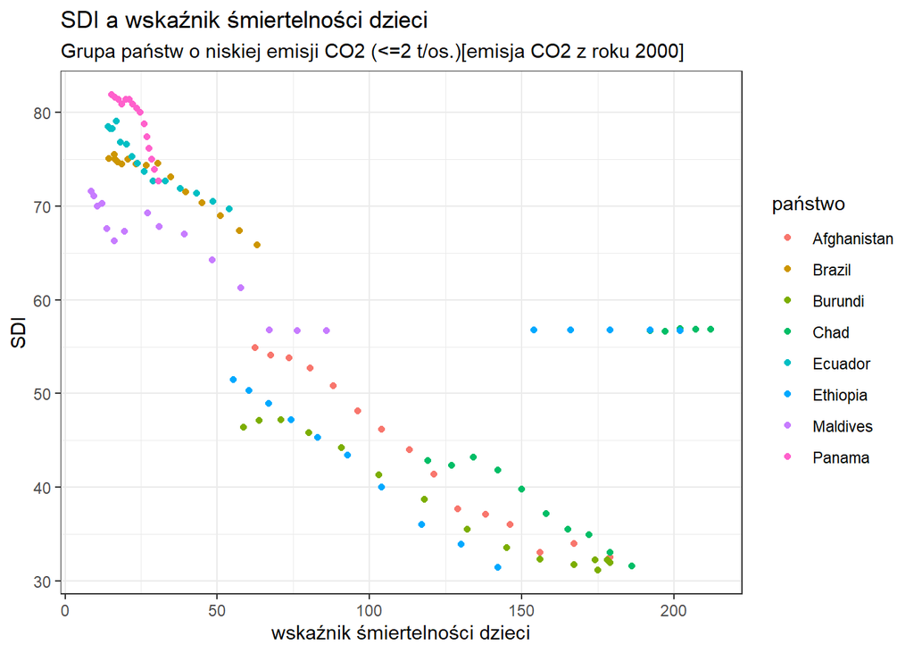

```r
co2_grupa1_top <- dane %>%
  filter(emisja_co2 <= 2) %>%
  filter(rok==2000) %>%
  slice_max(emisja_co2,n=4)
co2_grupa1_bot <- dane %>%
  filter(emisja_co2 <= 2) %>%
  filter(rok==2000) %>%
  slice_min(emisja_co2,n=4)

co2_grupa1_W <- rbind(co2_grupa1_bot, co2_grupa1_top)
co2_grupa1 <- dane %>%
  filter(panstwo %in% co2_grupa1_W$panstwo)

co2_grupa1 %>%
  ggplot(mapping = aes(x = smiertelnosc_dzieci,
                       y = sustainable_development_indeks,
                       col = panstwo)) +
  geom_point() +
    theme_bw() +
      labs(title = "SDI a wskaźnik śmiertelności dzieci",
          subtitle = "Grupa państw o niskiej emisji CO2 (<=2 t/os.)[emisja CO2 z roku 2000]",
          x = "wskaźnik śmiertelności dzieci",
          y = "SDI",
          col = "państwo")
```

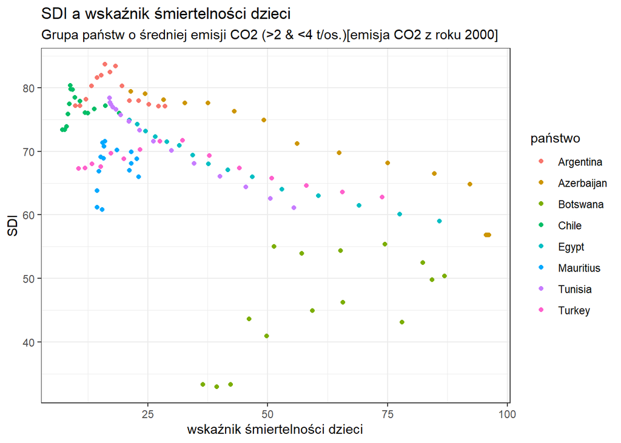

W grupie drugiej sytuacja ma się bardzo podobnie, tutaj jednak dla Botswany wskaźnik SDI rośnie wraz ze wzrostem wskaźnika śmiertelności dzieci.

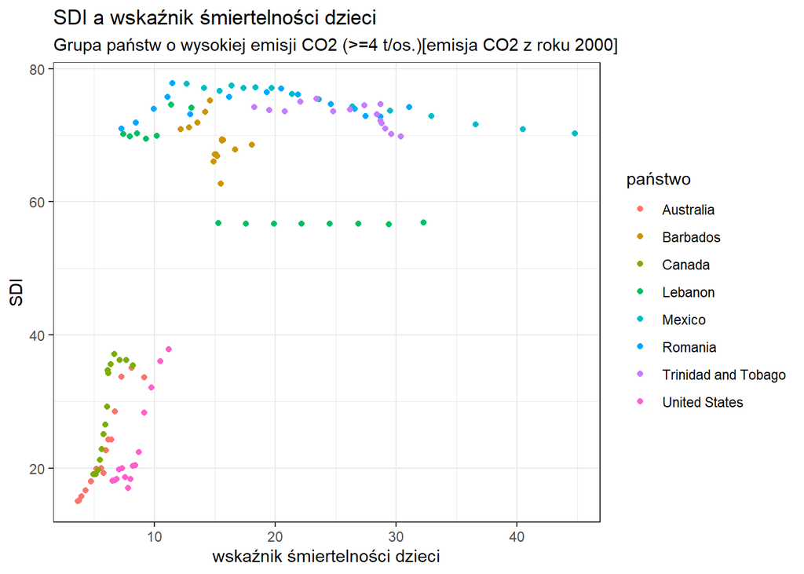

```
## [1] "Statystyki opisowe dla grupy 1 (wskaźnik śmiertelności dzieci, wskaźnik SDI):"
```

```
##    Min. 1st Qu.  Median    Mean 3rd Qu.    Max.
##    8.62   24.48   62.65   81.12  135.00  212.00
```

```
##    Min. 1st Qu.  Median    Mean 3rd Qu.    Max.
##   31.10   43.10   56.83   58.20   74.03   81.90
```

```
## [1] "Korelacja Spearmana pomiędzy zmiennymi w grupie 1 jest równa:"
```

```
## [1] -0.8268718
```

```
## [1] "Statystyki opisowe dla grupy 2 (wskaźnik śmiertelności dzieci, wskaźnik SDI):"
```

```
##    Min. 1st Qu.  Median    Mean 3rd Qu.    Max.
##    7.19   15.88   23.95   34.29   49.35   96.10
```

```
##    Min. 1st Qu.  Median    Mean 3rd Qu.    Max.
##   32.90   64.30   70.15   68.42   77.03   83.70
```

```
## [1] "Korelacja Spearmana pomiędzy zmiennymi w grupie 2 jest równa:"
```

```
## [1] -0.6524443
```

```
## [1] "Statystyki opisowe dla grupy 3 (wskaźnik śmiertelności dzieci, wskaźnik SDI):"
```

```
##    Min. 1st Qu.  Median    Mean 3rd Qu.    Max.
##   3.690   7.303  13.050  15.161  21.525  44.800
```

```
##    Min. 1st Qu.  Median    Mean 3rd Qu.    Max.
##   15.00   28.45   68.90   53.75   73.72   77.80
```

```
## [1] "Korelacja Spearmana pomiędzy zmiennymi w grupie 3 jest równa:"
```

```
## [1] 0.7050311
```

Po przeanalizowaniu wykresów i wyliczonych statystyk widać kierunek korelacji, w pierwszych dwóch grupach są to głównie zależności malejące, w grupie trzeciej państwa o niskich wartościach obu zmiennych zaburzają wielkość wskaźnika korelacji, jednak na ich przykładzie widać że nie dla każdego państwa zależność jest jednakowa. Powyższe wskaźniki korelacji są generalnie dość wysokie.

Na podstawie powyższej wizualizacji oraz analizy statystyk można uznać, że wysokość wskaźnika SDI jest mocno powiązana z wysokością wskaźnika śmiertelności dzieci.